# EDA Assignment 3

Motoki Sugino

September 15, 2016

For each of the two datasets below

Find 5-number summaries, fences, and outside values for each group (CITY). Construct parallel boxplots. Using a spread-vs-level plot, determine the power of a transformation that you believe will stabilize spread. Using the transformation, reanalyze the data by computing new 5-number summaries (and fence and outside values) and parallel boxplots. Was the transformation successful in stabilizing spread? If not, which alternative transformation might you try next? Discuss the differences you found between the groups and unusual data values (BE SPECIFIC AND MAKE COMPARISONS).

# Dataset 1

# Find 5-number summaries, fences, and outside values for each group (CITY).

```r
library(LearnEDA)
library(aplpack)
```

```r
#stem plot
#tapply(salaries$Salary,salaries$City,aplpack::stem.leaf)#Amsterdam,Athens,Bangkok,Hong_Kong,Los_Angeles,Singapore
#5-number summaries
fivenum1 <-tapply(salaries$Salary,salaries$City,summary);fivenum1
```

```
## $Amsterdam
##    Min. 1st Qu.  Median    Mean 3rd Qu.    Max.
##   266.0   310.0   341.0   381.1   424.0   593.0
##
## $Athens
##    Min. 1st Qu.  Median    Mean 3rd Qu.    Max.
##   106.0   117.5   161.0   172.3   192.0   320.0
##
## $Bangkok
##    Min. 1st Qu.  Median    Mean 3rd Qu.    Max.
##   31.00   34.50   37.00   69.71  101.50  148.00
##
## $Hong_Kong
##    Min. 1st Qu.  Median    Mean 3rd Qu.    Max.
##    59.0    96.0   116.0   127.0   159.5   203.0
##
## $Los_Angeles
##    Min. 1st Qu.  Median    Mean 3rd Qu.    Max.
##   179.0   308.5   326.0   362.7   412.0   593.0
##
## $Singapore
##    Min. 1st Qu.  Median    Mean 3rd Qu.    Max.
##    43.0    67.5    89.0   101.7    97.5   250.0
```

*This above table is 5 number summary (mean is not five number summary).

```r
library(dplyr)
Amsterdam<-c(266.0,310.0,341.0,381.4,424.0,593.0)
Athens<-c(106.0,117.5,161.0,172.3,192.0,320.0)
Bangkok<-c(31.00,34.50,37.00,69.71,101.50,148.00)
Hong_Kong<-c(59.0,96.0,116.0,127.0,159.5,203.0)
Los_Angeles<-c(179.0,308.5,326.0,362.7,412.0,593.0)
Singapore<-c(43.0,67.5,89.0,101.7,97.5,250.0)

Amsterdam<-c(310.0,424.0)
Athens<-c(117.5,192.0)
Bangkok<-c(34.50,101.50)
Hong_Kong<-c(96.0,159.5)
Los_Angeles<-c(308.5,412.0)
Singapore<-c(67.5,97.5)
Q3andQ1=as.data.frame(rbind(Amsterdam,Athens,Bangkok,Hong_Kong,Los_Angeles,Singapore))
rename(Q3andQ1,"1stQ"=V1,"3rdQ"=V2)
```

```
##              1stQ  3rdQ
## Amsterdam   310.0 424.0
## Athens      117.5 192.0
## Bangkok      34.5 101.5
## Hong_Kong    96.0 159.5
## Los_Angeles 308.5 412.0
## Singapore    67.5  97.5
```

```r
df=as.data.frame(rbind(cbind(Q3andQ1$V2-Q3andQ1$V1)))
rename(df,dF=V1)
```

```
##      dF
## 1 114.0
## 2  74.5
## 3  67.0
## 4  63.5
## 5 103.5
## 6  30.0
```

```r
STEP=as.data.frame(rbind(cbind(df$V1*1.5)))
rename(STEP,STEP=V1)
```

```
##     STEP
## 1 171.00
## 2 111.75
## 3 100.50
## 4  95.25
## 5 155.25
## 6  45.00
```

```r
Lowerfence=as.data.frame(rbind(cbind(Q3andQ1$V1-STEP$V1)))
Upperfence=as.data.frame(rbind(cbind(Q3andQ1$V2+STEP$V1)))
LowerfenceandUpperfence=as.data.frame(rbind(cbind(Lowerfence$V1,Upperfence$V1)))
rename(LowerfenceandUpperfence,Lowerfence=V1,Upperfence=V2)
```

```
##   Lowerfence Upperfence
## 1     139.00     595.00
## 2       5.75     303.75
## 3     -66.00     202.00
## 4       0.75     254.75
## 5     153.25     567.25
## 6      22.50     142.50
```

```r
LOWERFENCE=as.data.frame(rbind(cbind(Q3andQ1$V1-(2*STEP$V1))))
UPPERFENCE=as.data.frame(rbind(cbind(Q3andQ1$V2+(2*STEP$V1))))
LOWERFENCEandUPPERFENCE=as.data.frame(rbind(cbind(LOWERFENCE$V1,UPPERFENCE$V1)))
rename(LOWERFENCEandUPPERFENCE,LOWERFENCE=V1,UPPERFENCE=V2)
```

```
##   LOWERFENCE UPPERFENCE
## 1      -32.0      766.0
## 2     -106.0      415.5
## 3     -166.5      302.5
## 4      -94.5      350.0
## 5       -2.0      722.5
## 6      -22.5      187.5
```

```r
#Summary for fences
name<-rbind("Amsterdam","Athens","Bangkok","Hong_Kong","Los_Angeles","Singapore")
TableFences=as.data.frame(rbind(cbind(name,Q3andQ1$V1,Q3andQ1$V2,df$V1*1.5,Lowerfence$V1,Upperfence$V1,LOWERFENCE$V1,UPPERFENCE$V1)))
rename(TableFences,"1stQ"=V2,"3rdQ"=V3,STEP=V4,Lowerfence=V5,Upperfence=V6,LOWERFENCE=V7,UPPERFENCE=V8)
```

```
##            V1  1stQ  3rdQ   STEP Lowerfence Upperfence LOWERFENCE
## 1   Amsterdam   310   424    171        139        595        -32
## 2      Athens 117.5   192 111.75       5.75     303.75       -106
## 3     Bangkok  34.5 101.5  100.5        -66        202     -166.5
## 4   Hong_Kong    96 159.5  95.25       0.75     254.75      -94.5
## 5 Los_Angeles 308.5   412 155.25     153.25     567.25         -2
## 6   Singapore  67.5  97.5     45       22.5      142.5      -22.5
##   UPPERFENCE
## 1        766
## 2      415.5
## 3      302.5
## 4        350
## 5      722.5
## 6      187.5
```

*This above table is for 5-number summaries, fences.

```r
#outside values
Soutlier<-data.frame(Athens=c(320),
           Los_Angeles=c(593),
           Singapore=c(250));Soutlier
```

```
##   Athens Los_Angeles Singapore
## 1    320         593       250
```

There are total 3 outliers in the salaries data.

# Construct parallel boxplots.

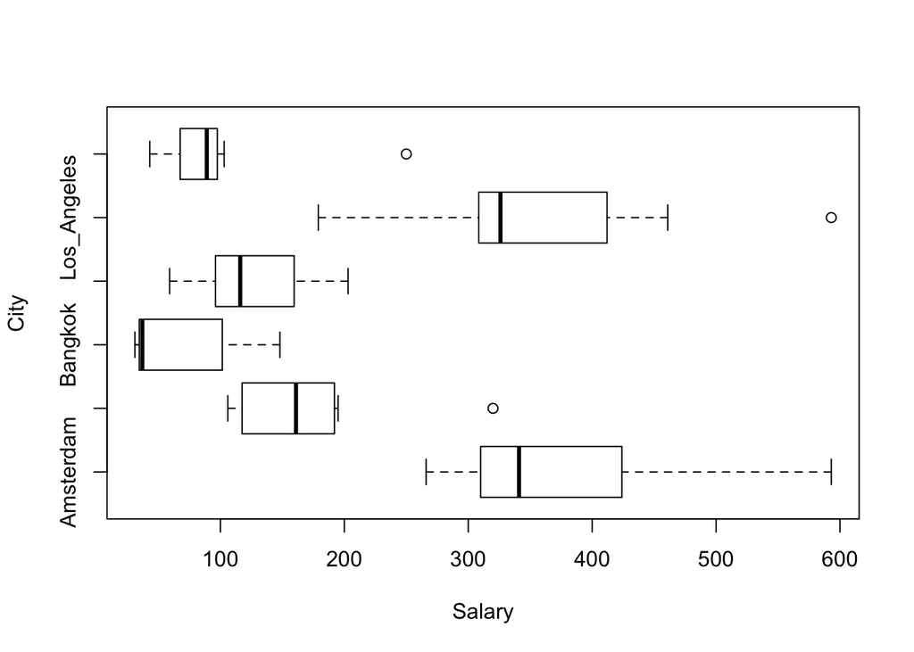

```
## $stats
##      [,1]  [,2]  [,3]  [,4]  [,5]  [,6]
## [1,]  266 106.0  31.0  59.0 179.0  43.0
## [2,]  310 117.5  34.5  96.0 308.5  67.5
## [3,]  341 161.0  37.0 116.0 326.0  89.0
## [4,]  424 192.0 101.5 159.5 412.0  97.5
## [5,]  593 195.0 148.0 203.0 461.0 103.0
## attr(,"class")
## Amsterdam
## "integer"
##
## $n
## [1] 7 7 7 7 7 7
##
## $conf
##         [,1]     [,2]      [,3]      [,4]     [,5]      [,6]
## [1,] 272.921 116.5098 -3.011319  78.07882 264.1915  71.08448
## [2,] 409.079 205.4902 77.011319 153.92118 387.8085 106.91552
##
## $out
## [1] 320 593 250
##
## $group
## [1] 2 5 6
##
## $names
## [1] "Amsterdam"   "Athens"      "Bangkok"     "Hong_Kong"   "Los_Angeles"
## [6] "Singapore"
```

```r
#Construct parallel boxplots.
Sboxplot<-boxplot(Salary ~ City, horizontal = TRUE,
         data = salaries, xlab = "Salary",
         ylab = "City");Sboxplot
```

*The boxplot for Amsterdam and Los_Angeles have wider spreads and have the similar median.

# Using a spread-vs-level plot, determine the power of a transformation that you believe will stabilize spread.

```r
#making new data set for spreadvslevel"Amsterdam","Athens","Bangkok","Hong_Kong","Los_Angeles","Singapore"
Ams=subset(salaries,City=="Amsterdam")
Ath=subset(salaries,City=="Athens")
Ban=subset(salaries,City=="Bangkok")
Hong=subset(salaries,City=="Hong_Kong")
Los=subset(salaries,City=="Los_Angeles")
Sin=subset(salaries,City=="Singapore")
newdata<-rbind(Ams,Ath,Ban,Hong,Los,Sin);newdata
```

```
##    Salary        City Profession
## 1     341   Amsterdam    Teacher
## 7     298   Amsterdam   Chauffer
## 13    266   Amsterdam   Mechanic
## 19    371   Amsterdam       Cook
## 25    593   Amsterdam    Manager
## 31    477   Amsterdam   Engineer
## 37    322   Amsterdam    Cashier
## 2     110      Athens    Teacher
## 8     106      Athens   Chauffer
## 14    125      Athens   Mechanic
## 20    195      Athens       Cook
## 26    320      Athens    Manager
## 32    189      Athens   Engineer
## 38    161      Athens    Cashier
```

[output cut: 28 more lines]

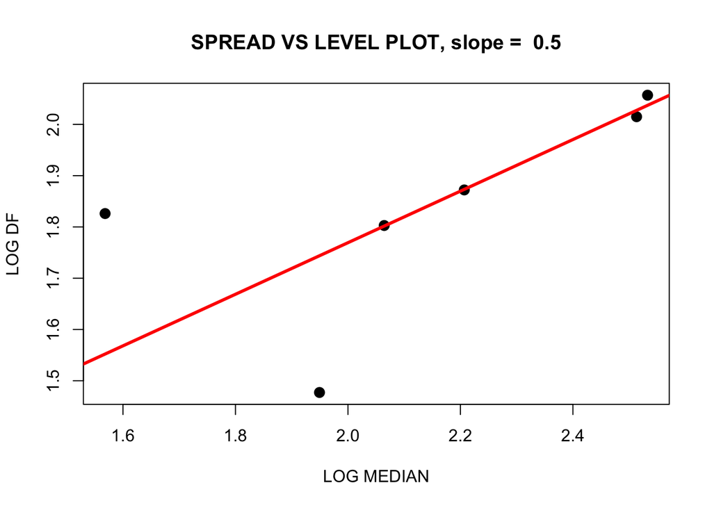

```
##         GROUP medians   dfs log.median   log.df
## 1   Amsterdam     341 114.0   2.532754 2.056905
## 2      Athens     161  74.5   2.206826 1.872156
## 3     Bangkok      37  67.0   1.568202 1.826075
## 4   Hong_Kong     116  63.5   2.064458 1.802774
## 5 Los_Angeles     326 103.5   2.513218 2.014940
## 6   Singapore      89  30.0   1.949390 1.477121
```

```r
#spread-vs-level plot
spread.level.plot(newdata$Salary, newdata$City)
```

```r
#How to find power
power=1-0.5
```

*I believe that the power of a transformation 0.5 will stabilize spread.

# Using the transformation, reanalyze the data by computing new 5-number summaries (and fence and outside values) and parallel boxplots.

```r
power=1-0.5
attach(newdata)
reexpressed.data <- data.frame(newdata$Salary^(power),newdata$City);reexpressed.data
```

```
##    newdata.Salary..power. newdata.City
## 1               18.466185    Amsterdam
## 2               17.262677    Amsterdam
## 3               16.309506    Amsterdam
## 4               19.261360    Amsterdam
## 5               24.351591    Amsterdam
## 6               21.840330    Amsterdam
## 7               17.944358    Amsterdam
## 8               10.488088       Athens
## 9               10.295630       Athens
## 10              11.180340       Athens
## 11              13.964240       Athens
## 12              17.888544       Athens
## 13              13.747727       Athens
## 14              12.688578       Athens
```

[output cut: 28 more lines]

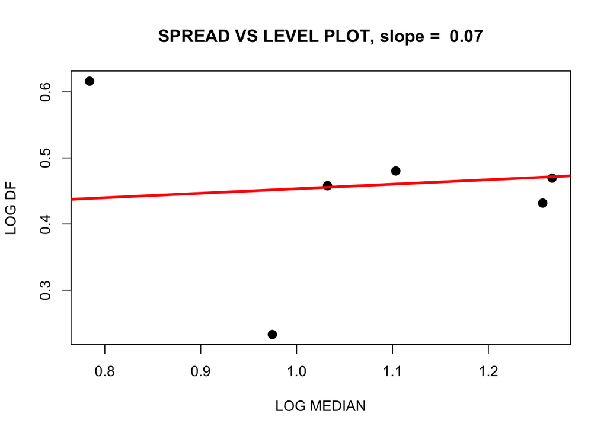

```
##         GROUP   medians      dfs log.median    log.df
## 1   Amsterdam 18.466185 2.947328  1.2663772 0.4694284
## 2      Athens 12.688578 3.021769  1.1034129 0.4802613
## 3     Bangkok  6.082763 4.132535  0.7841009 0.6162165
## 4   Hong_Kong 10.770330 2.870232  1.0322290 0.4579169
## 5 Los_Angeles 18.055470 2.702420  1.2566088 0.4317529
## 6   Singapore  9.433981 1.709509  0.9746950 0.2328715
```

```r
attach(reexpressed.data)
spread.level.plot(reexpressed.data$newdata.Salary..power., reexpressed.data$newdata.City)
```

```r
newfivesum<-tapply(reexpressed.data$newdata.Salary..power., reexpressed.data$newdata.City,summary);newfivesum #mean does not count as five number summary
```

```
## $Amsterdam
##    Min. 1st Qu.  Median    Mean 3rd Qu.    Max.
##   16.31   17.60   18.47   19.35   20.55   24.35
##
## $Athens
##    Min. 1st Qu.  Median    Mean 3rd Qu.    Max.
##   10.30   10.83   12.69   12.89   13.86   17.89
##
## $Bangkok
##    Min. 1st Qu.  Median    Mean 3rd Qu.    Max.
##   5.568   5.874   6.083   7.939  10.010  12.170
##
## $Hong_Kong
##    Min. 1st Qu.  Median    Mean 3rd Qu.    Max.
##   7.681   9.749  10.770  11.060  12.620  14.250
##
## $Los_Angeles
##    Min. 1st Qu.  Median    Mean 3rd Qu.    Max.
##   13.38   17.56   18.06   18.78   20.26   24.35
##
## $Singapore
##    Min. 1st Qu.  Median    Mean 3rd Qu.    Max.
##   6.557   8.161   9.434   9.695   9.870  15.810
```

```r
#fences for reexpresseddata
Ams1=subset(reexpressed.data$newdata.Salary..power.,reexpressed.data$newdata.City=="Amsterdam")
Ams1.five<-as.vector(fivenum(Ams1))
Ath1=subset(reexpressed.data$newdata.Salary..power.,reexpressed.data$newdata.City=="Athens")
Ath1.five<-as.vector(fivenum(Ath1))
Ban1=subset(reexpressed.data$newdata.Salary..power.,reexpressed.data$newdata.City=="Bangkok")
Ban1.five<-as.vector(fivenum(Ban1))
Hong1=subset(reexpressed.data$newdata.Salary..power.,reexpressed.data$newdata.City=="Hong_Kong")
Hong1.five<-as.vector(fivenum(Hong1))
Los1=subset(reexpressed.data$newdata.Salary..power.,reexpressed.data$newdata.City=="Los_Angeles")
Los1.five<-as.vector(fivenum(Los1))
Sin1=subset(reexpressed.data$newdata.Salary..power.,reexpressed.data$newdata.City=="Singapore")
Sin1.five<-as.vector(fivenum(Sin1))

newdata2<-rbind(Ams1.five,Ath1.five,Ban1.five,Hong1.five,Los1.five,Sin1.five)
FNStable=as.data.frame(newdata2,row.names=c("Amsterdam","Athens","Bangkok","Hong_Kong","Los_Angeles","Singapore"))
colnames(FNStable)=c("min","firstQ","median","thirdQ","max")
newSTEP=1.5*(FNStable$thirdQ-FNStable$firstQ)
newLowerfence=FNStable$firstQ-newSTEP
newUpperfence=FNStable$thirdQ+newSTEP
newLOWERFENCE=FNStable$firstQ-2*newSTEP
newUPPERFENCE=FNStable$thirdQ-2*newSTEP
newtable=cbind(FNStable,newLowerfence,newUpperfence,newLOWERFENCE,newUPPERFENCE)

#outliers for reexpressed data
re.outlier<-data.frame(Los_Angeles=c(13.37909, 24.35159),
                       Singapore=c(15.81139," "));re.outlier
```

```
##   Los_Angeles Singapore
## 1    13.37909  15.81139
## 2    24.35159
```

*There are totall three outlires in reexpressed data : Two outlirers in Los_Angeles and there is one in Singapore.

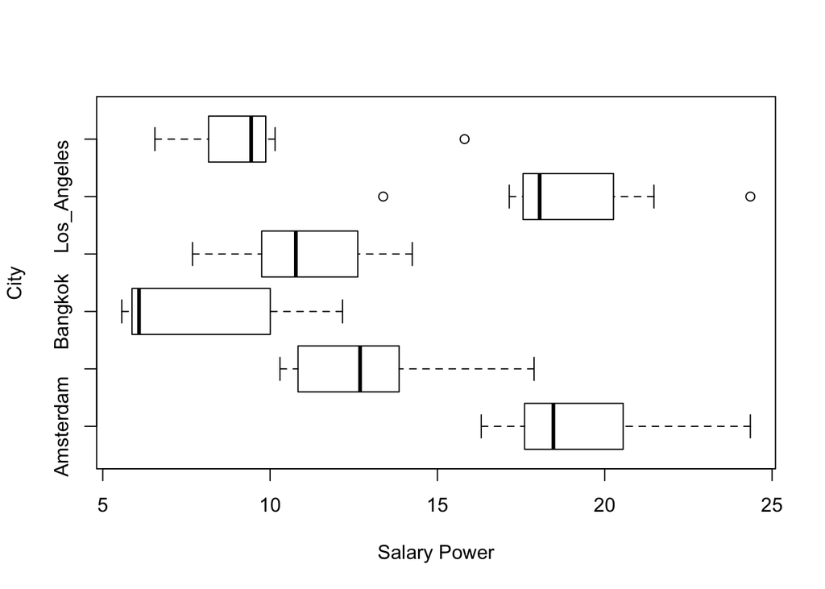

```
## $stats
##          [,1]     [,2]      [,3]      [,4]     [,5]      [,6]
## [1,] 16.30951 10.29563  5.567764  7.681146 17.14643  6.557439
## [2,] 17.60352 10.83421  5.873516  9.749385 17.55931  8.160768
## [3,] 18.46619 12.68858  6.082763 10.770330 18.05547  9.433981
## [4,] 20.55084 13.85598 10.006050 12.619616 20.26173  9.870277
## [5,] 24.35159 17.88854 12.165525 14.247807 21.47091 10.148892
##
## $n
## [1] 7 7 7 7 7 7
##
## $conf
##          [,1]     [,2]     [,3]      [,4]     [,5]     [,6]
## [1,] 16.70609 10.88403 3.614880  9.056274 16.44163  8.41309
## [2,] 20.22628 14.49313 8.550645 12.484386 19.66931 10.45487
##
## $out
## [1] 24.35159 13.37909 15.81139
##
## $group
## [1] 5 5 6
##
## $names
## [1] "Amsterdam"   "Athens"      "Bangkok"     "Hong_Kong"   "Los_Angeles"
## [6] "Singapore"
```

```r
#parallel boxplots for reexpressed data
reexpressed.data <- data.frame(SP=newdata$Salary^(power),City=newdata$City)
rex.boxplot<-boxplot(SP ~ City, horizontal = TRUE,
         data = reexpressed.data, xlab = "Salary Power",
         ylab = "City");rex.boxplot
```

# Was the transformation successful in stabilizing spread? If not, which alternative transformation might you try next?

```r
#Comparing the spreads side by side
comps1<-as.data.frame(rbind(114.0,74.5,67.0,63.5,103.5,30.0))
comps2<-as.data.frame(rbind(2.947328,3.021769,4.132535,2.870232,2.702420,1.709509))
comps<-data.frame(comps1,comps2)
rename(comps,dFraw=V1,dFreexp=V1.1)
```

```
##   dFraw  dFreexp
## 1 114.0 2.947328
## 2  74.5 3.021769
## 3  67.0 4.132535
## 4  63.5 2.870232
## 5 103.5 2.702420
## 6  30.0 1.709509
```

```r
114/30
```

```
## [1] 3.8
```

```r
4.132535/1.709509
```

```
## [1] 2.417381
```

The spreads of the raw data range from 30 to 114-the largest spread is 3.8 times the smallest. The spreads of the reexpressed data range from 4.132535 to 1.709509-the largest spread is 2.417381 times the smallest. This is an improvement.

# Discuss the differences you found between the groups and unusual data values (BE SPECIFIC AND MAKE COMPARISONS).

# Dataset 2

```r
library(LearnEDA)
island.areas
```

```
##            Ocean                                      Name   Area
## 1         Arctic                             Axel_Heilberg  16671
## 2         Arctic                                    Baffin 195928
## 3         Arctic                                     Banks  27038
## 4         Arctic                                  Bathurst   6194
## 5         Arctic                                     Devon  21331
## 6         Arctic                                 Ellesmere  75767
## 7         Arctic                                  Melville  16274
## 8         Arctic                           Prince_of_Wales  12872
## 9         Arctic                                  Xomerset   9570
## 10        Arctic                               Southampton  15913
## 11        Arctic                                  Victoria  83896
## 12        Arctic                          Franz_Josef_Land   8000
## 13        Arctic                             Novaya_Zemiya  35000
## 14        Arctic                                   Wrangel   2800
```

[output cut: 45 more lines]

# Find 5-number summaries, fences, and outside values for each group (CITY).

```r
library(aplpack)
#stem plot
#tapply(island.areas$Area,island.areas$Ocean,aplpack::stem.leaf)
#5-number summaries
fivenum2 <-tapply(island.areas$Area,island.areas$Ocean,summary);fivenum2
```

```
## $Arctic
##    Min. 1st Qu.  Median    Mean 3rd Qu.    Max.
##    2800   11220   16670   36750   31020  195900
##
## $Caribbean
##    Min. 1st Qu.  Median    Mean 3rd Qu.    Max.
##      59     124     290    5707    2690   44220
##
## $East_Indies
##    Min. 1st Qu.  Median    Mean 3rd Qu.    Max.
##    2113    5673   21430   62540   63980  280100
##
## $Indian
##     Min.  1st Qu.   Median     Mean  3rd Qu.     Max.
##    171.0    575.0    844.5  32170.0   8208.0 226700.0
##
## $Mediterranean
##    Min. 1st Qu.  Median    Mean 3rd Qu.    Max.
##    86.0   385.5  1936.0  3049.0  3470.0  9822.0
```

```r
#fences for the Artic Ocean, Caribbean Sea, Indian Ocean, Mediterranean Sea and East Indies
Arctic=subset(island.areas$Area,island.areas$Ocean=="Arctic")
Arctic.five<-as.vector(fivenum(Arctic))
Caribbean=subset(island.areas$Area,island.areas$Ocean=="Caribbean")
Caribbean.five<-as.vector(fivenum(Caribbean))
Indian=subset(island.areas$Area,island.areas$Ocean=="Indian")
Indian.five<-as.vector(fivenum(Indian))
Mediterranean=subset(island.areas$Area,island.areas$Ocean=="Mediterranean")
Mediterranean.five<-as.vector(fivenum(Mediterranean))
East_Indies=subset(island.areas$Area,island.areas$Ocean=="East_Indies")
East_Indies.five<-as.vector(fivenum(East_Indies))

FNSdata2<-rbind(Arctic.five,Caribbean.five,Indian.five,Mediterranean.five,East_Indies.five)


FNStable2=as.data.frame(FNSdata2,row.names=c("Arctic","Caribbean","Indian","Mediterranean","East_Indies"))
colnames(FNStable2)=c("min","firstQ","median","thirdQ","max")

newSTEP2=1.5*(FNStable2$thirdQ-FNStable2$firstQ)
newLowerfence2=FNStable2$firstQ-newSTEP2
newUpperfence2=FNStable2$thirdQ+newSTEP2
newLOWERFENCE2=FNStable2$firstQ-2*newSTEP2
newUPPERFENCE2=FNStable2$thirdQ-2*newSTEP2
newtable2=cbind(FNStable2,newLowerfence2,newUpperfence2,newLOWERFENCE2,newUPPERFENCE2)

#outliers　for "Arctic","Caribbean","Indian","Mediterranean","East_Indies"
Soutlier<-data.frame(Arctic=c(75767,83896,195928),
           Caribbean=c(29530,44218," "),
           Indian=c(280100," "," "),
           Mediterranean=c(226658," "," "),
           East_Indies=c(9262,9822," "));Soutlier
```

[output not shown]

*There are total 9 outliers in the island.areas data

# Construct parallel boxplots.

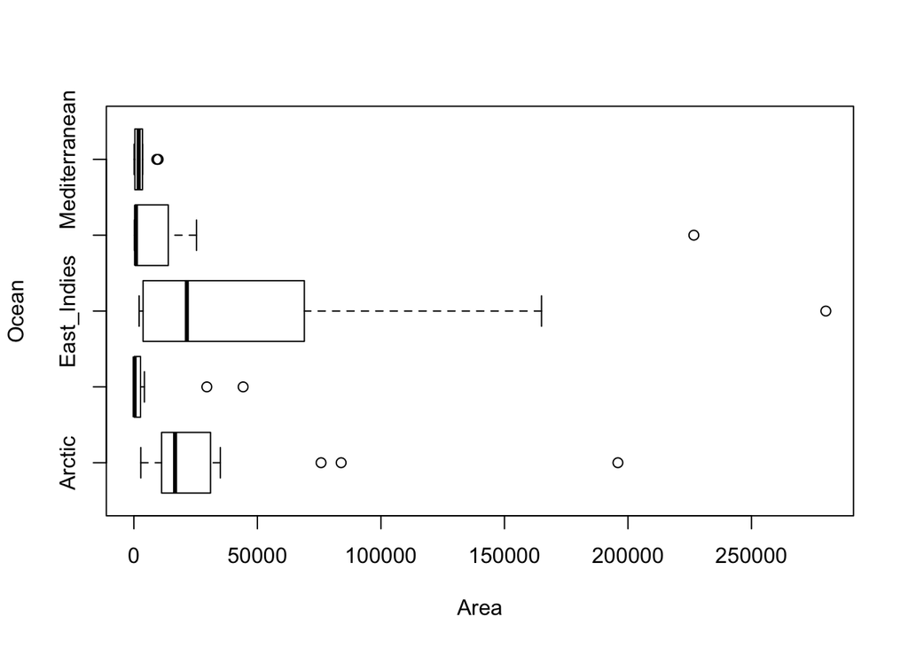

```
## $stats
##       [,1]   [,2]     [,3]    [,4]   [,5]
## [1,]  2800   59.0   2113.0   171.0   86.0
## [2,] 11221  124.0   3707.0   510.0  385.5
## [3,] 16671  290.0  21429.5   844.5 1936.0
## [4,] 31019 2689.5  69000.0 13916.0 3470.5
## [5,] 35000 4244.0 165000.0 25332.0 3572.0
## attr(,"class")
##    Arctic
## "integer"
##
## $n
## [1] 15 15 10  8 11
##
## $conf
##           [,1]      [,2]      [,3]      [,4]      [,5]
## [1,]  8594.322 -756.6066 -11193.49 -6644.284  466.3433
## [2,] 24747.678 1336.6066  54052.49  8333.284 3405.6567
##
## $out
## [1] 195928  75767  83896  44218  29530 280100 226658   9262   9822
##
## $group
## [1] 1 1 1 2 2 3 4 5 5
##
## $names
## [1] "Arctic"        "Caribbean"     "East_Indies"   "Indian"
## [5] "Mediterranean"
```

```r
boxplot2<-boxplot(Area ~ Ocean, horizontal = TRUE,
         data = island.areas, xlab = "Area",
         ylab = "Ocean");boxplot2
```

*While East_Indies has a wider spread, others have a narrow spreads. East_Indies and Arctic have the similar median. So there appears to be a dependence between spread and level here.

# Using a spread-vs-level plot, determine the power of a transformation that you believe will stabilize spread.

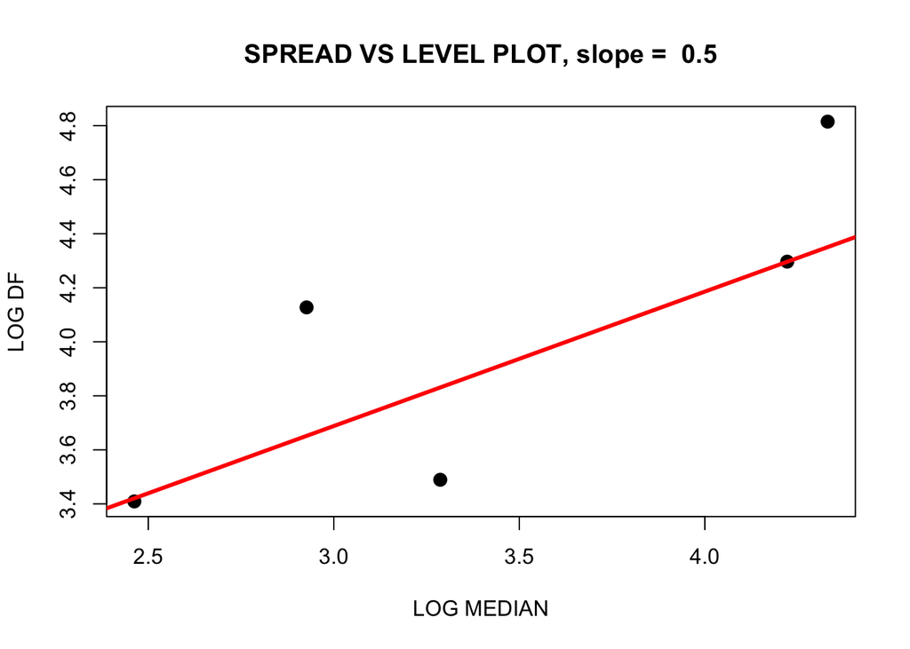

```
##           GROUP medians     dfs log.median   log.df
## 1        Arctic 16671.0 19798.0   4.221962 4.296621
## 2     Caribbean   290.0  2565.5   2.462398 3.409172
## 3        Indian 21429.5 65293.0   4.331012 4.814867
## 4 Mediterranean   844.5 13406.0   2.926600 4.127299
## 5   East_Indies  1936.0  3085.0   3.286905 3.489255
```

```r
#spread-vs-level plot
spread.level.plot(island.areas$Area, island.areas$Ocean)
```

```r
#How to find power
power=1-0.5
```

*For now, I believe that the power of a transformation 0.5 will stabilize spread.

# Using the transformation, reanalyze the data by computing new 5-number summaries (and fence and outside values) and parallel boxplots.

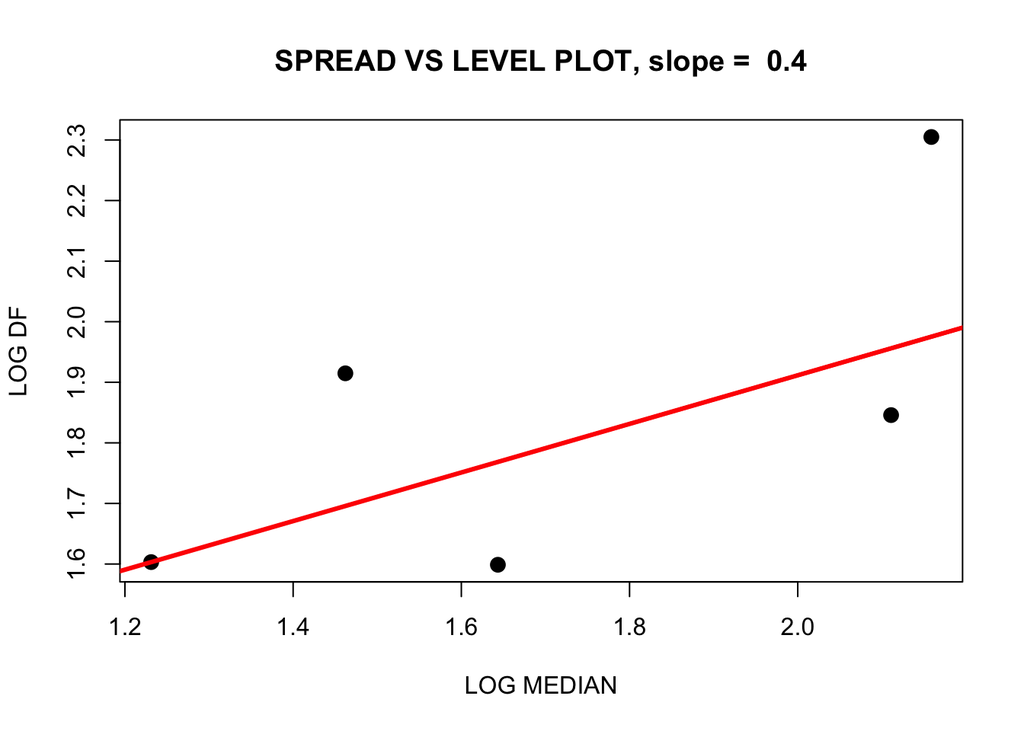

```
##           GROUP   medians       dfs log.median   log.df
## 1        Arctic 129.11623  70.11701   2.110981 1.845823
## 2     Caribbean  17.02939  40.10102   1.231199 1.603155
## 3        Indian 144.15968 201.79337   2.158844 2.304907
## 4 Mediterranean  28.98079  82.18424   1.462110 1.914789
## 5   East_Indies  44.00000  39.69783   1.643453 1.598767
```

```r
power=1-0.5
reexpressed.data2 <- data.frame(AreaPower=island.areas$Area^(power),Ocean=island.areas$Ocean)

attach(reexpressed.data2)
spread.level.plot(reexpressed.data2$AreaPower, reexpressed.data2$Ocean)
```

```r
newfivesum2<-tapply(reexpressed.data2$AreaPower, reexpressed.data2$Ocean,summary);newfivesum2
```

```
## $Arctic
##    Min. 1st Qu.  Median    Mean 3rd Qu.    Max.
##   52.92  105.60  129.10  165.00  175.80  442.60
##
## $Caribbean
##    Min. 1st Qu.  Median    Mean 3rd Qu.    Max.
##   7.681  11.130  17.030  45.900  51.230 210.300
##
## $East_Indies
##    Min. 1st Qu.  Median    Mean 3rd Qu.    Max.
##   45.97   72.55  144.20  196.80  252.30  529.20
##
## $Indian
##    Min. 1st Qu.  Median    Mean 3rd Qu.    Max.
##   13.08   23.85   28.98  100.10   77.29  476.10
##
## $Mediterranean
##    Min. 1st Qu.  Median    Mean 3rd Qu.    Max.
##   9.274  19.210  44.000  46.350  58.900  99.110
```

```r
#mean does not count as five number summary
```

```r
#fences for reexpressed data the Artic Ocean, Caribbean Sea, Indian Ocean, Mediterranean Sea and East Indies
Arctic=subset(reexpressed.data2$AreaPower,reexpressed.data2$Ocean=="Arctic")
Arctic.five<-as.vector(fivenum(Arctic))
Caribbean=subset(reexpressed.data2$AreaPower,reexpressed.data2$Ocean=="Caribbean")
Caribbean.five<-as.vector(fivenum(Caribbean))
Indian=subset(reexpressed.data2$AreaPower,reexpressed.data2$Ocean=="Indian")
Indian.five<-as.vector(fivenum(Indian))
Mediterranean=subset(reexpressed.data2$AreaPower,reexpressed.data2$Ocean=="Mediterranean")
Mediterranean.five<-as.vector(fivenum(Mediterranean))
East_Indies=subset(reexpressed.data2$AreaPower,reexpressed.data2$Ocean=="East_Indies")
East_Indies.five<-as.vector(fivenum(East_Indies))

FNSdata2<-rbind(Arctic.five,Caribbean.five,Indian.five,Mediterranean.five,East_Indies.five)


FNStable2=as.data.frame(FNSdata2,row.names=c("Arctic","Caribbean","Indian","Mediterranean","East_Indies"))
colnames(FNStable2)=c("min","firstQ","median","thirdQ","max")

newSTEP2=1.5*(FNStable2$thirdQ-FNStable2$firstQ)
newLowerfence2=FNStable2$firstQ-newSTEP2
newUpperfence2=FNStable2$thirdQ+newSTEP2
newLOWERFENCE2=FNStable2$firstQ-2*newSTEP2
newUPPERFENCE2=FNStable2$thirdQ-2*newSTEP2
newtable2=cbind(FNStable2,newLowerfence2,newUpperfence2,newLOWERFENCE2,newUPPERFENCE2);newtable2
```

```
##                     min    firstQ    median    thirdQ      max
## Arctic        52.915026 105.64061 129.11623 175.75761 442.6375
## Caribbean      7.681146  11.12973  17.02939  51.23075 210.2808
## Indian        13.076697  22.39590  28.98079 104.58015 476.0861
## Mediterranean  9.273618  19.20682  44.00000  58.90465  99.1060
## East_Indies   45.967380  60.88514 144.15968 262.67851 529.2447
##               newLowerfence2 newUpperfence2 newLOWERFENCE2 newUPPERFENCE2
## Arctic             0.4650974       280.9331     -104.71041      -34.59341
## Caribbean        -49.0218077       111.3823     -109.17334      -69.07232
## Indian          -100.8804600       227.8565     -224.15682     -141.97258
## Mediterranean    -40.3399247       118.4514      -99.88667      -60.18884
## East_Indies     -241.8049217       565.3686     -544.49498     -342.70161
```

```r
#outliers　for "Arctic","Caribbean","Indian","Mediterranean","East_Indies"
Soutlier<-data.frame(Arctic=c(442.63754924317," "),
                     Caribbean=c(171.84295155752,210.280764693302),
                     Mediterranean=c(476.086126661973," "));Soutlier
```

[output not shown]

*There are totall 4 outliers.

# Was the transformation successful in stabilizing spread? If not, which alternative transformation might you try next?

*No, The transformation was not successfull since there is positive relationship between spread and level We will try to use 0.2 as a power.

```r
power=1-0.8
reexpressed.data2 <- data.frame(AreaPower=island.areas$Area^(power),Ocean=island.areas$Ocean)
attach(reexpressed.data2)
```

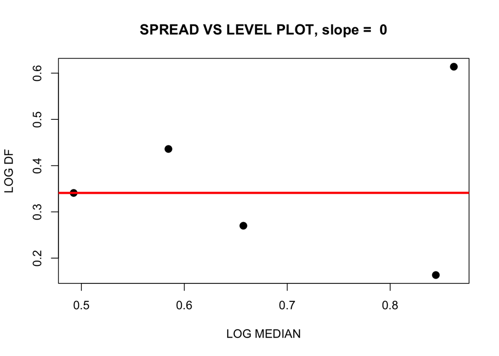

```
##           GROUP  medians      dfs log.median    log.df
## 1        Arctic 6.988635 1.456865  0.8443923 0.1634194
## 2     Caribbean 3.107990 2.192609  0.4924796 0.3409612
## 3        Indian 7.276003 4.111003  0.8618929 0.6139477
## 4 Mediterranean 3.841998 2.729307  0.5845572 0.4360524
## 5   East_Indies 4.543401 1.862276  0.6573811 0.2700441
```

```r
spread.level.plot(reexpressed.data2$AreaPower, reexpressed.data2$Ocean)
```

```r
newfivesum2<-tapply(reexpressed.data2$AreaPower, reexpressed.data2$Ocean,summary);newfivesum2
```

```
## $Arctic
##    Min. 1st Qu.  Median    Mean 3rd Qu.    Max.
##   4.891   6.445   6.989   7.442   7.902  11.440
##
## $Caribbean
##    Min. 1st Qu.  Median    Mean 3rd Qu.    Max.
##   2.260   2.621   3.108   3.962   4.814   8.494
##
## $East_Indies
##    Min. 1st Qu.  Median    Mean 3rd Qu.    Max.
##   4.624   5.504   7.276   7.678   9.130  12.290
##
## $Indian
##    Min. 1st Qu.  Median    Mean 3rd Qu.    Max.
##   2.796   3.551   3.842   5.195   5.486  11.780
##
## $Mediterranean
##    Min. 1st Qu.  Median    Mean 3rd Qu.    Max.
##   2.437   3.243   4.543   4.371   5.106   6.287
```

*Now we do not see much of a relationship between logM and logdF in this plot, suggesting that we have removed the trend between spread and level.

```r
Arctic=subset(reexpressed.data2$AreaPower,reexpressed.data2$Ocean=="Arctic")
Arctic.five<-as.vector(fivenum(Arctic))
Caribbean=subset(reexpressed.data2$AreaPower,reexpressed.data2$Ocean=="Caribbean")
Caribbean.five<-as.vector(fivenum(Caribbean))
Indian=subset(reexpressed.data2$AreaPower,reexpressed.data2$Ocean=="Indian")
Indian.five<-as.vector(fivenum(Indian))
Mediterranean=subset(reexpressed.data2$AreaPower,reexpressed.data2$Ocean=="Mediterranean")
Mediterranean.five<-as.vector(fivenum(Mediterranean))
East_Indies=subset(reexpressed.data2$AreaPower,reexpressed.data2$Ocean=="East_Indies")
East_Indies.five<-as.vector(fivenum(East_Indies))

FNSdata2<-rbind(Arctic.five,Caribbean.five,Indian.five,Mediterranean.five,East_Indies.five)


FNStable2=as.data.frame(FNSdata2,row.names=c("Arctic","Caribbean","Indian","Mediterranean","East_Indies"))
colnames(FNStable2)=c("min","firstQ","median","thirdQ","max")

newSTEP2=1.5*(FNStable2$thirdQ-FNStable2$firstQ)
newLowerfence2=FNStable2$firstQ-newSTEP2
newUpperfence2=FNStable2$thirdQ+newSTEP2
newLOWERFENCE2=FNStable2$firstQ-2*newSTEP2
newUPPERFENCE2=FNStable2$thirdQ-2*newSTEP2
newtable2=cbind(FNStable2,newLowerfence2,newUpperfence2,newLOWERFENCE2,newUPPERFENCE2);newtable2
```

```
##                    min   firstQ   median   thirdQ       max newLowerfence2
## Arctic        4.891382 6.445351 6.988635 7.902216 11.439823      4.2600531
## Caribbean     2.260322 2.621437 3.107990 4.814046  8.494148     -0.6674763
## Indian        2.796400 3.460877 3.841998 6.190184 11.778072     -0.6330830
## Mediterranean 2.437248 3.243346 4.543401 5.105622  6.286950      0.4499316
## East_Indies   4.623596 5.173739 7.276003 9.284742 12.287474     -0.9927648
##               newUpperfence2 newLOWERFENCE2 newUPPERFENCE2
## Arctic             10.087514       2.074755      3.5316204
## Caribbean           8.102959      -3.956390     -1.7637808
## Indian             10.284144      -4.727043     -1.9977364
## Mediterranean       7.899037      -2.343483     -0.4812066
## East_Indies        15.451245      -7.159269     -3.0482660
```

```r
#outliers　for "Arctic","Caribbean","Indian","Mediterranean","East_Indies"
Soutlier<-data.frame(Arctic=c(11.4398228965051),
           Mediterranean=c(11.778072151889));Soutlier
```

[output not shown]

```r
#Comparing the spreads side by side
comps1<-as.data.frame(rbind(19798.0,2565.5,65293.0,13406.0,3085.0))
comps2<-as.data.frame(rbind(1.456865,2.192609,4.111003,2.729307,1.862276))
comps<-data.frame(comps1,comps2)
rename(comps,dFraw=V1,dFreexp=V1.1)
```

```
##     dFraw  dFreexp
## 1 19798.0 1.456865
## 2  2565.5 2.192609
## 3 65293.0 4.111003
## 4 13406.0 2.729307
## 5  3085.0 1.862276
```

```r
65293.0/2565.5
```

```
## [1] 25.4504
```

```r
4.111003/1.456865
```

```
## [1] 2.821815
```

*The spreads of the raw data range from 2565.5 to 65293.0-the largest spread is 25.4504 times the smallest. The spreads of the reexpressed data range from 4.111003 to 1.456865-the largest spread is 2.821815 times the smallest. This is an big improvement - it probably make sence to use the reexpressed data.

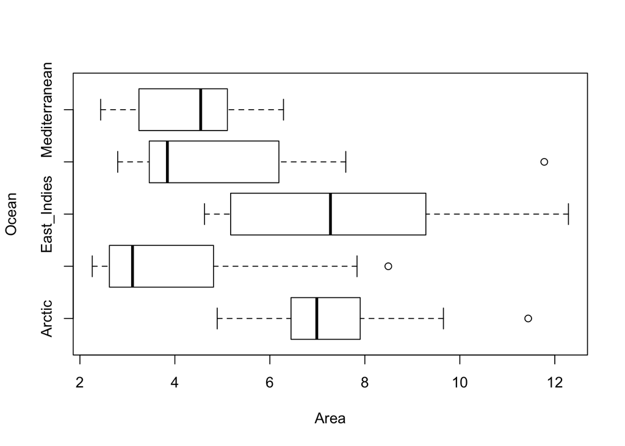

```
## $stats
##          [,1]     [,2]      [,3]     [,4]     [,5]
## [1,] 4.891382 2.260322  4.623596 2.796400 2.437248
## [2,] 6.445351 2.621437  5.173739 3.460877 3.243346
## [3,] 6.988635 3.107990  7.276003 3.841998 4.543401
## [4,] 7.902216 4.814046  9.284742 6.190184 5.105622
## [5,] 9.654910 7.835247 12.287474 7.598605 6.286950
##
## $n
## [1] 15 15 10  8 11
##
## $conf
##          [,1]     [,2]     [,3]     [,4]     [,5]
## [1,] 6.394300 2.213506 5.221982 2.317368 3.656235
## [2,] 7.582969 4.002474 9.330024 5.366628 5.430567
##
## $out
## [1] 11.439823  8.494148 11.778072
##
## $group
## [1] 1 2 4
##
## $names
## [1] "Arctic"        "Caribbean"     "East_Indies"   "Indian"
## [5] "Mediterranean"
```

```r
boxplot3<-boxplot(AreaPower ~ Ocean, horizontal = TRUE,
          data = reexpressed.data2, xlab = "Area",
          ylab = "Ocean");boxplot3
```

*This plot looks better than before. However, East_Indies still has the largest spread of a batch.

# Discuss the differences you found between the groups and unusual data values (BE SPECIFIC AND MAKE COMPARISONS).

Before fransforming the datasets,in the parallel boxplots we could see the extreamly large value next to the right whiskers in all Ocean. Moreover, the spreads of batches are narrow except East_Indies.

However, after transforming the datasets, there are only three outliers(in Arctic, Caribbean and Indian) in parallel boxplots. There are no extream outliers in Mediterranean and East_Indies. Moreover, all of batches are roughly equal spreaded except East_indies.(East_indies seems a little bit wider).